*diagnostics*

[figure not shown]

[figure not shown]

[figure not shown]

*Review*

**Inhibition of Androgen Signalling Improves the Outcomes of**

**Therapies for Bladder Cancer: Results from a Systematic**

**Review of Preclinical and Clinical Evidence and Meta-Analysis**

**of Clinical Studies**

**Massimiliano Creta** <sup>**1**</sup>**, Giuseppe Celentano** <sup>**1**</sup>**, Luigi Napolitano** <sup>**1**</sup>**, Roberto La Rocca** <sup>**1,**</sup>*, Marco Capece <sup>**1**</sup>**,**

**Gianluigi Califano** <sup>**1**</sup>**, Claudia Coll****à** **Ruvolo** <sup>**1**</sup>**, Francesco Mangiapia** <sup>**1**</sup>**, Simone Morra** <sup>**1**</sup>

**, Carmine Turco** <sup>**1**</sup>**,**

**Lorenzo Spirito** <sup>**1**</sup>**, Ferdinando Fusco** <sup>**2**</sup>**, Ciro Imbimbo** <sup>**1**</sup>**, Vincenzo Mirone** <sup>**1**</sup>**and Nicola Longo** <sup>**1**</sup>

**Citation:** Creta, M.; Celentano, G.;

Napolitano, L.; La Rocca, R.; Capece,

M.; Califano, G.; Collà Ruvolo, C.;

Mangiapia, F.; Morra, S.; Turco, C.;

et al. Inhibition of Androgen

Signalling Improves the Outcomes of

Therapies for Bladder Cancer: Results

from a Systematic Review of

Preclinical and Clinical Evidence and

Meta-Analysis of Clinical Studies.

*Diagnostics* **2021**, *11*, 351. https://

doi.org/10.3390/diagnostics11020351

Academic Editor: Hideki Furuya

Received: 29 January 2021

Accepted: 18 February 2021

Published: 20 February 2021

**Publisher’s Note:** MDPI stays neutral

with regard to jurisdictional claims in

published maps and institutional afﬁl-

iations.

[figure not shown]

**Copyright:** © 2021 by the authors.

Licensee MDPI, Basel, Switzerland.

This article is an open access article

distributed

under

the

terms

and

conditions of the Creative Commons

Attribution (CC BY) license (https://

creativecommons.org/licenses/by/

4.0/).

1

Department of Neurosciences, Science of Reproduction and Odontostomatology, University of Naples

Federico II, 80131 Naples, Italy; massimiliano.creta@unina.it (M.C.); giuseppe.celentano2@unina.it (G.C.);

luigi.napolitano12@studenti.unina.it (L.N.); marco.capece@unina.it (M.C.); Gianluigi.califano@unina.it (G.C.);

claudia.collaruvolo@unina.it (C.C.R.); Francesco.mangiapia@unina.it (F.M.); simone.morra@unina.it (S.M.);

carmine.turco2@unina.it (C.T.); Lorenzo.spirito@unina.it (L.S.); ciro.imbimbo@unina.it (C.I.);

mirone@unina.it (V.M.); nicola.longo@unina.it (N.L.)

2

Department of Woman, Child and General and Specialized Surgery, Urology Unit, University of Campania

‘Luigi Vanvitelli’, 80131 Naples, Italy; ferdinando.fusco@unicampania.it

Correspondence: roberto.larocca@unina.it

**Abstract:** Bladder cancer (BCa) is an endocrine-related tumour and the activation of androgen

signalling pathways may promote bladder tumorigenesis. We summarized the available preclinical

and clinical evidence on the implications of the manipulation of androgen signalling pathways

on the outcomes of BCa therapies. A systematic review was performed in December 2020. We

included papers that met the following criteria: original preclinical and clinical research; evaluating

the impact of androgen signalling modulation on the outcomes of BCa therapies. Six preclinical and

eight clinical studies were identiﬁed. The preclinical evidence demonstrates that the modulation of

androgen receptor-related pathways has the potential to interfere with the activity of the Bacillus

Calmette Guerin, doxorubicin, cisplatin, gemcitabine, and radiotherapy. The relative risk of BCa

recurrence after transurethral resection of the bladder tumour (TURBT) is signiﬁcantly lower in

patients undergoing therapy with 5 alpha reductase inhibitors (5-ARIs) or androgen deprivation

therapy (ADT) (Relative risk: 0.50, 95% CI: 0.30–0.82; *p* = 0.006). Subgroup analysis in patients

strategy aimed at reducing BCa recurrence rate, mainly in patients with low stage disease. Further

studies are needed to conﬁrm these preliminary data.

**Keywords:**

5 alpha reductase inhibitors; androgen deprivation therapy; androgen receptor;

bladder cancer

**1. Introduction**

Bladder cancer (BCa) is the ninth most common cancer worldwide and the seventh

most common in men [1]. Despite advances in therapy, the management of BCa patients

remains suboptimal in both the early and advanced stages. Transurethral resection of

the bladder tumour (TURBT) represents the standard surgical procedure for nonmuscle

invasive BCa [2]. However, cancer recurrence and progression to muscle invasive disease

has been described despite risk-reducing strategies such as intravesical chemo- and/or

immunotherapy [3]. Radical cystectomy (RC) with pelvic lymph node dissection and

urinary diversion represents the standard of care for patients with muscle-invasive disease

*Diagnostics* **2021**, *11*, 351. https://doi.org/10.3390/diagnostics11020351

https://www.mdpi.com/journal/diagnostics

*Diagnostics* **2021**, *11*, 351

2 of 15

and for selected patients with high-risk, nonmuscle invasive disease [4]. However, BCa

relapses approximately 50% of patients following RC. External beam radiotherapy (EBRT)

is supported by low-level evidence and should only be considered as a therapeutic option

when the patient is unﬁt for RC or as part of a multimodality bladder-preserving approach.

Therefore, new treatment strategies have been advocated to improve the outcomes of

treatments for BCa [3]. The evidence demonstrates signiﬁcant gender-related differences

in patients with BCa in terms of both incidence and natural history [5]. Indeed, incidence

is higher in males with a male-to-female ratio of 3.5:1, while advanced stage at the time

of diagnosis and rapid progression are commonly observed in females [5]. The role of

androgen signalling in BCa has been proven in preclinical and clinical settings and these

ﬁndings have potential relevant therapeutic implications [6,7]. Emerging evidence also

indicates that the manipulation of androgen signalling may inﬂuence BCa behaviour [8]. A

previous systematic review and meta-analysis screening articles published up to April 2019

showed that BCa incidence was signiﬁcantly lower in patients receiving therapy with 5-a

reductase inhibitor (5-ARIs) or androgen deprivation therapy (ADT) [3]. Moreover, ADT

has been reported to reduce BCa recurrence after TURBT [3]. These preliminary ﬁndings

stimulated further research on the topic. Herein, we aimed to summarize the available

preclinical and clinical ﬁndings in order to provide an updated overview of evidence

about the impact of the modulation of androgen signalling pathways on the outcomes of

therapies for BCa.

**2. Materials and Methods**

This analysis was conducted and reported according to the general guidelines rec-

ommended by the Primary Reporting Items for Systematic Reviews and Meta-analyses

(PRISMA) statement [9].

*2.1. Literature Search*

The search was performed in the Medline (US National Library of Medicine, Bethesda,

MD, USA), Scopus (Elsevier, Amsterdam, The Netherlands), and Web of Science Core

Collection (Thomson Reuters, Toronto, ON, Canada) databases up to December 2020. The

following terms were combined to capture relevant publications: “bladder cancer” AND

(“transurethral resection of bladder tumour” OR “transurethral resection of bladder tumor”

OR “radical cystectomy” OR “radiotherapy” OR “intravesical chemotherapy” OR “intrav-

esical immunotherapy” OR “Bacillus Calmette-Guérin” OR “systemic chemotherapy”)

AND (“androgen” OR “androgen receptor” OR “androgen deprivation therapy” OR “du-

tasteride” OR “ﬁnasteride” OR “castration” OR “LHRH agonist” OR “LHRH antagonists”).

Reference lists in relevant articles and reviews were also screened for additional studies.

*2.2. Selection Criteria*

Two authors (M.C. and N.L.) reviewed the records separately and individually to select

relevant publications, with any discrepancies resolved by a third author (L.N.). To assess

the eligibility for the systematic review, PICOS (participants, intervention, comparisons,

outcomes, study type) criteria were used. PICOS criteria for preclinical studies were set as

follows: (P)articipants—animal, in vitro, in vivo models of urothelial BCa; (I)ntervention—

modulation of androgen signalling; (C)omparator—none; (O)utcome: evaluation of the

impact of the modulation of androgen signalling on treatments used for BCa; (S)tudy

types—animal, in vitro, in vivo studies.

PICOS criteria for clinical studies were set as follows: (P)articipants—BCa patients un-

dergoing therapies for BCa; (I)ntervention—modulation of androgen signalling (C)omparat-

or—patients not undergoing modulation androgen signalling; (O)utcome: BCa-speciﬁc

outcomes; (S)tudy types—prospective and retrospective studies, case series.

*Diagnostics* **2021**, *11*, 351

3 of 15

*2.3. Data Collection*

The following data were extracted from preclinical studies: ﬁrst author, year of

publication, study design, study model, type of androgen signalling pathway modulation,

study groups, type of BCa treatment, ﬁndings, involved pathway.

The following data were extracted from clinical studies: ﬁrst author, study design,

BCa stage and grade, patients’ gender and age, type and duration of androgen signalling

modulation, comparators, type of BCa treatment, follow-up duration, outcome assessed.

Risk of bias for clinical studies was assessed using the Risk of Bias in Nonrandomized

Studies of Interventions (ROBINS-I) tool [10].

*2.4. Statistical Analysis*

The meta-analysis was performed by ProMeta 3 software when there were two or more

studies reporting the same outcome under the same deﬁnition. The effect size (ES) was

estimated by Risk Ratio (RR) reported with its 95% conﬁdence interval (CI). Heterogeneity

among studies was evaluated using the I<sup>2</sup>statistics. A *p* <0.05 was considered statistically

signiﬁcant. To calculate the pooled effect, a random effect model was applied. Egger’s

linear regression test and Begg and Mazumdar’s rank correlation test were also used to

evaluate the publication bias of studies included in the meta-analysis. A metaregression

analysis was used to assess the relationship between the ratio of patients with T1 BCa

among those treated with 5-ARIs/controls and the RR of tumour recurrence. Subgroup

analyses were performed according to the strategy of androgen signalling manipulation.

**3. Results**

The search strategy revealed a total of 320 results. The screening of the titles and the

abstracts deﬁned 58 papers eligible for inclusion. Further assessment of eligibility, based

on the study of the full-text papers, led to the exclusion of 44 papers. Finally, 14 studies

(6 preclinical and 8 clinical) were included in the ﬁnal analysis (Figure 1) [11–24]. Of these,

6 studies were included in the quantitative synthesis.

*3.1. Evidence from Preclinical Studies*

Overall, six preclinical studies were identiﬁed investigating the effects of the manipu-

lation of androgen signalling on the outcomes of therapies for BCa [11–16] (Table 1).

**Table 1.** Summary of preclinical studies.

**Study**

**Study**

**Design**

**Model**

**Androgen-**

**Related**

**Pathway**

**Manipulation**

**BCa**

**Treatment**

**Outcome**

**Assessed**

**Findings**

**Involved**

**Pathway**

Mizushima

[11]

In vitro

Cell Lines

(UMUC3,

TCCSUP, and

5637-AR)

AR knockdown

AR

overexpression

BCG

Amount of

intracellular BCG

*↑* amount of

intracellular BCG

in AR knockdown cell lines,

*↓* amount of intracellular

BCG in AR-positive cells, *↓*

amount of intracellular

BCG in AR

overexpression cells

Rab27b

Rate of BCG

positive cells

*↑* rate of BCG positive cells

in AR knockdown cell lines,

*↓* rate of BCG positive cells

in AR-positive cells, *↓* rate

of BCG positive cells in AR

overexpression cells

BCG activity

*↑* BCG activity in AR

knockdown cell lines, *↓* in

AR-positive cells, *↓* BCG

activity in AR

overexpression cells

*Diagnostics* **2021**, *11*, 351

4 of 15

**Table 1.** *Cont.*

**Study**

**Study**

**Design**

**Model**

**Androgen-**

**Related**

**Pathway**

**Manipulation**

**BCa**

**Treatment**

**Outcome**

**Assessed**

**Findings**

**Involved**

**Pathway**

Ide [12]

In vitro

Cell lines

(UMUC3,

5637-AR, and

647V-AR)

HF

DHT, AR

overexpression,

and AR

knockdown

RT

Radiosensitivity

*↑* radiosensitivity following

AR inactivation, less

signiﬁcant decrease of cell

viability following

exposure to DHT, delay of

doublestrand break repair

following AR knockdown

ATR,

CHEK1, and

PARP-1

In vivo

Mouse

xenograft

Flutamide

*↑* inhibitory effects of

irradiation following

AR inactivation

n/a

Shang [13]

In vitro

Cell line (253J)

AR degradation

enhancer

ASC-J9HF

BCG

BCG attachment/

internalization

*↑* BCG

attachment/internalization

to BCa cells following

exposure to HF

and ASC-J9®

Integrin

α5β1

Monocytes/

macrophages

recruitment

*↑* recruitment of

monocytes/macrophages

following exposure to HF

and ASC-J9®

IL6

expression

BCG activity

*↑* BCG intra-cellular

efﬁcacy to suppress BCa

cell proliferation following

exposure to HF or ASC-J9®

HMGB1

release

In vivo

BBN- induced

BCa mouse

model

ASC-J9

BCG activity

*↑* BCG efﬁcacy to suppress

BCa cell proliferation

following exposure

to ASCJ9®

n/a

Shiota [14]

In vitro

Cell lines

(UMUC3 and

MBT-2)

Bicalutamide

and Flutamide

CT

Doxorubicin

activity

*↑* doxorubicin activity

following exposure to

AR antagonists

n/a

Kashiwagi

[15]

In vitro

Cell lines

(UMUC3,

647V-AR,

5637-AR)

Synthetic

androgen R1881,

HF, AR

overexpression,

and AR

knockdown

CT

Cisplatin activity

*↓* cisplatin activity

following exposure to

R1881, *↑* cisplatin activity

following exposure to HF

NF-κB

Kameyama

[16]

In vitro

Gemcitabine-

resistant

T24 cells

Enzalutamide

CT

Gemcitabine

activity

*↑* gemcitabile ctivity

following exposure to

enzalutamide

Cyclin D1

expression

253J: human BCa cell line 253J; 647-V: human urothelial bladder carcinoma; 5637: Human bladder carcinoma cell line; AR: Androgen

Receptor; BBN: N-butyl-N-(4-hydroxybutyl) nitrosamine; BCG: Bacillus Calmette Guerin; CT: Chemotherapy; DHT: dihydrotestostrone;

HF: Hydroxyﬂutamide; HMGB1: High Mobility Group Box 1; IL: Interleukin; MBT-2: Mouse Bladder Tumor line-2; RT: Radiotherapy;

TCCSUP: Human urinary bladder transitional cell carcinoma; UMUC3: Human Bladder Transitional Cell Carcinoma; *↑*: increase;

*↓*: reduction.

Two studies investigated the effects of the inhibition of androgen signalling on the

interaction between BCG and BCa cell lines in in vitro and in vivo models [11,13]. The au-

thors showed an increased amount of intracellular BCG, increased rate of BCG positive cells,

increased BCG-related cytotoxic activity, increased recruitment of monocytes/macrophages

and decreased cell proliferation following the inhibition of androgen signalling in in vitro

models [11,13]. The suppression of BCa cell proliferation following the inhibition of an-

drogen signalling was also proven in an in vivo mouse model [13]. Molecular pathways

involved in improved BCG efﬁcacy following the inhibition of androgen signalling include

Rab27b, interleukin 6, integrin α5β1, High Mobility Group Box 1.

One study investigated the effects of ﬂutamide and its major active metabolite hy-

droxyﬂutamide on the radiosensitivity of BCa cells in in vivo and in vitro settings, respec-

tively [12]. The authors demonstrated the enhanced inhibitory effects of radiation following

*Diagnostics* **2021**, *11*, 351

5 of 15

inactivation of the androgen receptor mediated by the modulation of the ATR, CHEK1 and

PARP-1 pathways [12].

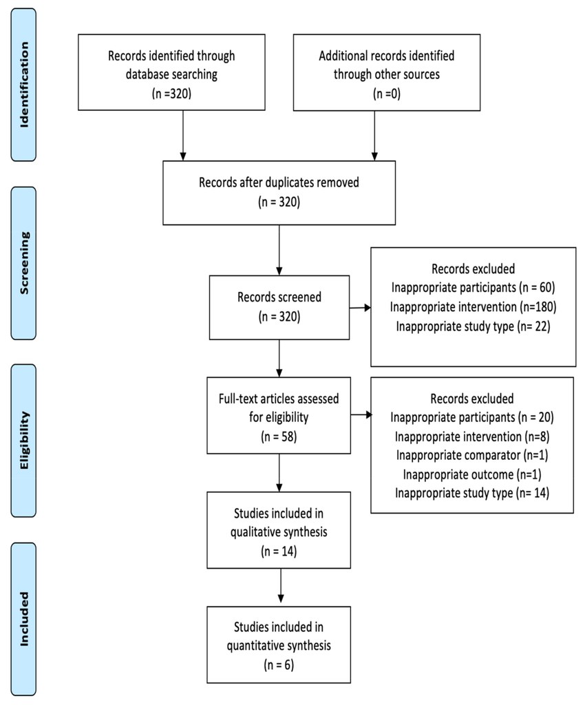

**Figure 1.** Flow diagram of the systematic review.

One study investigated the effects of androgen receptor blockage on BCa cell lines

exposed to doxorubicin by showing increased drug activity [14].

One study investigated the impact of androgen receptor activation on cisplatin sensi-

tivity by demonstrating reduced cisplatin sensitivity following exposure to the synthetic

androgen R1881 [15].

One study investigated the effects of enzalutamide on cell growth following exposure

to gemcitabile and found decreased cell viability following exposure to enzalutamide [16].

*3.2. Evidence from Clinical Studies*

Overall, eight retrospective case-control studies were identiﬁed involving a total

of 17,454 male patients [17–24]. The study characteristics, patients’ demographics and

tumour features are summarized in Table 2. The manipulation of the androgen signalling

pathway involved the use of 5-ARIs in 771patients (dutasteride, ﬁnasteride, and unspeciﬁed

drug in 215, 8, and 548 patients, respectively), gonadotropin-releasing hormone agonists

in 10 patients, peripheral antiandrogen in 7 patients, gonadotropin-releasing hormone

agonists and/or peripheral antiandrogen in 13 patients and unspeciﬁed drug in 86 patients.

BCa treatment modality included TURBT (7 studies), RC (2 studies), RT (1 study). The

following outcomes were assessed: recurrence-free survival, progression-free survival,

cancer-speciﬁc survival, overall survival. The risk of bias evaluation with ROBINS-I

indicates the presence of a moderate bias for all studies (Table 3).

*Diagnostics* **2021**, *11*, 351

6 of 15

**Table 2.** Summary of clinical studies.

**Study**

**Sample**

**Size**

**(n)**

**BCa**

**Stage, (n)**

**BCa Grade**

**Age,**

**Years,**

**Mean**

**(Range)**

**Androgen Dependent**

**Signalling Pathway**

**Modulation**

**Exposure**

**(n) vs Com-**

**parator**

**(n)**

**BCa**

**Treat-**

**ment**

**Type (n)**

**Adjuvant**

**Intravesical**

**Chemotherapy**

**(n)**

**FU (y)**

**Outcome**

**Findings**

**Risk**

**Estimate**

**Low**

**(n)**

**High**

**(n)**

**Type (n)**

**Duration**

**(months)**

Pastore

[22]

312

pTa (117)

pT1 (165)

*≥*pT2 (30)

92

220

75.1 (n/a)

Dutasteride

(165)

*≥*12

5-ARI (165)

vs no 5-ARI

(147)

TURBT

(312)

MMC (129)

BCG (153)

2.6

RFS

*↑* in 5-ARI

users

HR: 0.64 (95%

CI: 0.58–0.87)

*p* = 0.006

PR

No

signiﬁcant

difference

RR: 1.43 (95%

CI: 0.15–13.36)

*p* = 0.755

Al-

Hogbani

[17]

206

pTa (96)

pT1 (82)

n/a (28)

29

177

70.0(68–

71)

Finasteride

(8)

Dutasteride

(31)

>6

5-ARI (39)

vs no 5-ARI

(167)

TURBT

(206)

BCG (206)

3.3

RFS

users

HR: 1.00 (95%

CI: 0.55–1.79)

*p* = 0.72

Wang

[23]

5214

n/a

n/a

n/a

76.5 (n/a)

Finasteride

(n/a)

Dutasteride

(n/a)

n/a

5-ARI (474)

vs no 5-ARI

(4740)

TURBT

(5214)

n/a

n/a

MR

*↓* in 5-ARI

users

OR: 0.826

(95% CI:

0.7–0.97)

*p* = 0.018

RFS

No

signiﬁcant

difference

OR: 0.960

(95% CI:

0.83–1.12)

*p* = 0.109

Wu

[20]

274

n/a

n/a

n/a

68.3 (n/a)

5-ARI (26)

GnRH

agonist (10)

and/or an-

tiandrogen

(7)

19 <sup>§</sup>

AST (36) vs

no AST

(238)

TURBT

(274)

BCG (245)

MMC (20)

Other (5)

3.1

RFS

*↑* in AST

users

HR: 0.53 (95%

CI: 0.30–0.88)

*p* = 0.01

PFS

No

signiﬁcant

difference

5-yr PFS with

vs without

AST: 80% vs

63%

*p* = 0.23

PR

No

signiﬁcant

difference

RR: 0.47 (95%

CI: 0.20–1.09)

*p* = 0.079

*Diagnostics* **2021**, *11*, 351

7 of 15

**Table 2.** *Cont.*

**Study**

**Sample**

**Size**

**(n)**

**BCa**

**Stage, (n)**

**BCa Grade**

**Age,**

**Years,**

**Mean**

**(Range)**

**Androgen Dependent**

**Signalling Pathway**

**Modulation**

**Exposure**

**(n) vs Com-**

**parator**

**(n)**

**BCa**

**Treat-**

**ment**

**Type (n)**

**Adjuvant**

**Intravesical**

**Chemotherapy**

**(n)**

**FU (y)**

**Outcome**

**Findings**

**Risk**

**Estimate**

**Low**

**(n)**

**High**

**(n)**

**Type (n)**

**Duration**

**(months)**

McMartin

[18]

338

pTis (34)

pTa (6)

pT1 (31)

pT2 (63)

pT3 (136)

pT4 (68)

129

209

n/a

Finasteride

(n/a)

Dutasteride

(n/a)

n/a

5-ARI (48)

vs no 5-ARI

(290)

RC (338)

n/a

3.0

OS

*↑* in 5-ARI

users

HR for OS

0.40 (95% CI:

0.19–0.83)

*p* = 0.015

CSS

No

signiﬁcant

difference

*p* = 0.3

RFS

No

signiﬁcant

difference

n/a

Makela

[19]

10720

n/a

n/a

n/a

n/a

Finasteride

(n/a)

Dutasteride

(n/a)

n/a

5-ARI (n/a)

vs no 5-ARI

(n/a)

TURBT

(n/a) RC

(n/a)

EBRT

(n/a)

CT (n/a)

n/a

4.2

CSS

*↓* in 5-ARI

users

HR: 0.77 (95%

CI 0.68–0.88)

*p* = n/a

Shiota

[21]

228

pTa (157)

pT1 (50)

pTis (21)

101

127

70.0

(63–78)

GnRH

agonist or

bicalu-

tamide

(13)Dutas-

teride

(19)

28 <sup>§</sup>

AST (32) vs

no AST

(196)

TURBT

(228)

None/single

chemotherapeu-

tic agent (51)

Continuous

chemotherapeu-

tic agent (109)

BCG (68)

3.6

RFS

*↑* in AST

users

HR: 0.36 (95%

CI: 0.11–0.89)

*p* = 0.024

PR

No

signiﬁcant

difference

RR: 0.46 (95%

CI: 0.03- 7.96)

*p* = 0.593

*Diagnostics* **2021**, *11*, 351

8 of 15

**Table 2.** *Cont.*

**Study**

**Sample**

**Size**

**(n)**

**BCa**

**Stage, (n)**

**BCa Grade**

**Age,**

**Years,**

**Mean**

**(Range)**

**Androgen Dependent**

**Signalling Pathway**

**Modulation**

**Exposure**

**(n) vs Com-**

**parator**

**(n)**

**BCa**

**Treat-**

**ment**

**Type (n)**

**Adjuvant**

**Intravesical**

**Chemotherapy**

**(n)**

**FU (y)**

**Outcome**

**Findings**

**Risk**

**Estimate**

**Low**

**(n)**

**High**

**(n)**

**Type (n)**

**Duration**

**(months)**

Izumi

[24]

162

pTa (105)

pT1 (49)

114

37

72.7

(54–92)

n/a

n/a

ADT (86) vs

no ADT

(76)

TURBT

(162)

Antracyclines

(38)

BCG (38)

13.0

RFS

*↑* in ADT

users

HR 0.29 (95%

CI: 0.17–0.49)

*p* < 0.001

PR

No

signiﬁcant

difference

RR: 1.77 (95%

CI:

0.16–19.11)

*p* = 0.639

5-ARI: 5 α reductase inhibitor; ADT: androgen deprivation therapy; AST: androgen suppression therapy; BCa: Bladder cancer; BCG: Bacillus Calmette–Guérin; CI: Conﬁdential interval; CSS: Cancer speciﬁc

survival; FSR: free survival rate; HR: Hazard ratio; FU: Follow-up; GnRH: Gonadotropin releasing hormone; IQR: Interquartile range; MIBC: Muscular invasive bladder cancer; MMC: Mitomycin; MR: Mortality

rate; OR: Odds ratio; OS: Overall survival; PFS: Progression free survival; PR: Progression rate; R: Retrospective; RFS: Recurrence free survival; TURBT: Transurethral resection of bladder; §: Median value;

y: Years; RC: Radical cystectomy; EBRT: External Beam Radiotherapy; CT: Chemotherapy; *↑*: increase; *↓*: reduction.

**Table 3.** Summary of risk of bias among included studies using Risk of Bias In Nonrandomized Studies - of Interventions (ROBINS-I) tool.

**Al-Hogbani [****17****]**

**McMartin [****18****]**

**Mäkelä [****19****]**

**Wu [****20****]**

**Shiota [****21****]**

**Pastore [****22****]**

**Wang [****23****]**

**Izumi [****24****]**

Bias due to confounding

M

M

M

M

M

M

M

M

Bias in selection of participants into

the study

L

L

M

L

L

L

M

L

Bias in classiﬁcation of interventions

M

L

L

L

L

L

L

M

Bias due to deviations from

intended interventions

M

L

M

L

L

L

M

L

Bias due to missing data

L

L

n/a

S

n/a

n/a

n/a

n/a

Bias in measurement of outcomes

L

L

M

L

M

M

M

M

Bias in selection of the reported result

L

S

L

L

L

L

L

M

Overall

M

M

M

M

M

M

M

M

L: Low; M: Moderate; S: Serious; n/a: data not available.

*Diagnostics* **2021**, *11*, 351

9 of 15

3.2.1. BCa Recurrence Following TURBT

CI: 0.30–0.82, *p* = 0.006) in patients undergoing therapy with 5-ARIs or ADT compared to

controls (Figure 2).

[figure not shown]

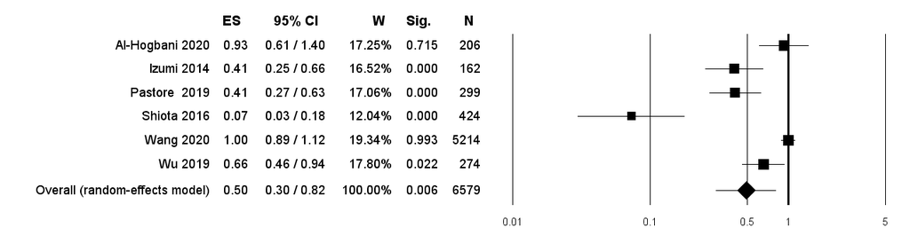

[figure not shown]

**Figure 2.** Forest plot showing the association between use of (5-ARIs) or androgen deprivation therapy (ADT) and the Risk

Ratio (RR) of bladder cancer (BCa) recurrence. ES: Effect Size; CI: Conﬁdence Interval. (I<sup>2</sup>= 91.4, *p* = 0.000).

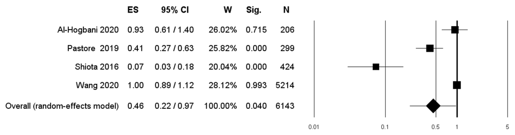

**Figure 3.** Forest plot showing the association between use of 5-ARIs and the RR of BCa recurrence. ES: Effect Size;

CI: Conﬁdence Interval. (I<sup>2</sup>= 93.4, *p* = 0.000).

patients with T1 BCa among those not treated with 5-ARIs and the RR of BCa recurrence

(*p*:0.014) (Figure 4).

3.2.2. BCa Progression

BCa progression was investigated in 4 studies [17,20,21,24]. The overall pooled data

showed a nonstatistically signiﬁcant lower RR in patients undergoing therapy with 5-ARIs

or ADT compared to controls (RR: 0.60, 95% CI: 0.29–1.23, *p* = 0.160) (Figure 5).

data from these two studies revealed a RR of BCa progression of 0.93 (95% CI: 0.16–5.39;

*p* = 0.933) (Figure 6).

3.2.3. BCa Recurrence Following RC

One study investigated the impact of therapy with 5-ARIs on recurrence free survival

following RC [18]. The use of 5-ARIs was not an independent predictor of recurrence free

survival [18].

*Diagnostics* **2021**, *11*, 351

10 of 15

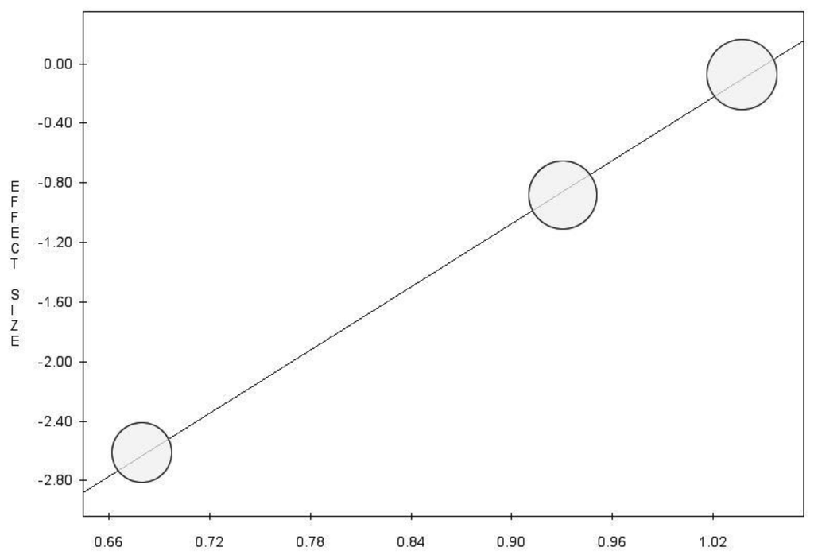

**Figure 4.** Metaregression of the proportion of patients with T1 BCa among those treated with 5-ARIs /

proportion of patients with T1 BCa among those not treated with 5-ARIs and the RR of BCa recurrence

on the RR of BCa recurrence (y = *−*7.44 + 7.07 x, *p* = 0.014).

[figure not shown]

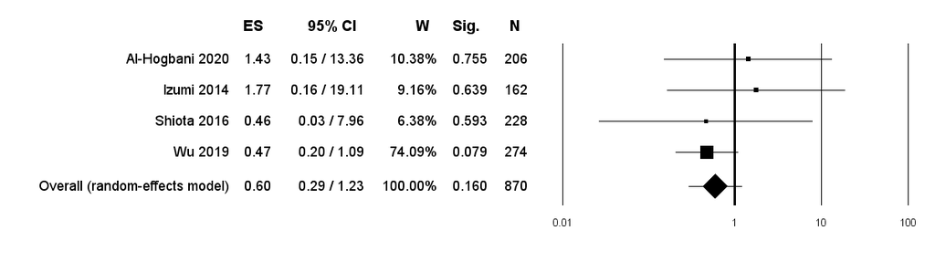

**Figure 5.** Forest plot showing the association between use of 5-ARIs or ADT and the RR of BCa progression. ES: Effect Size;

CI: Conﬁdence Interval. (I<sup>2</sup>= 0.00, *p* = 0.633).

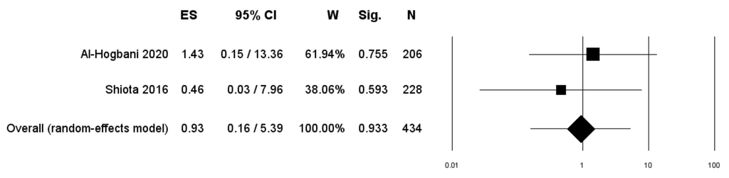

**Figure 6.** Forest plot showing the association between use of 5-ARIs and the RR of BCa progression. ES: Effect Size; CI:

Conﬁdence Interval. (I<sup>2</sup>= 0.00, *p* = 0.540).

3.2.4. BCa-Related Mortality

BCa-related mortality was investigated in three studies [18,19,23]. In the study by

Wang et al. the number of deaths caused by BCa was 163 (34.39%) and 1873 (39.51%) in

the 5-ARIs, and in the control group, respectively [23]. Compared to nonusers, patients

who received 5-ARIs showed a lower risk of BCa death in multivariable adjusted analysis

*Diagnostics* **2021**, *11*, 351

11 of 15

multivariable adjusted analysis (HR: 0.85 and 0.77, respectively) [19]. McMartin et al. failed

to ﬁnd signiﬁcant differences for 5-ARI use on cancer speciﬁc survival after RC on adjusted

Cox regression analysis [18].

Bias evaluation is reported in Figures 7–9.

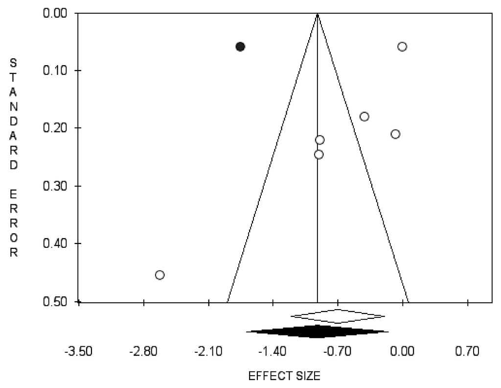

**Figure 7.** Funnel plots of the meta-analysis evaluating the association between use of 5-ARIs or

ADT and the RR of BCa recurrence. Egger’s linear regression (t = *−*3.84, *p* = 0.019) and Begg and

Mazumdar rank correlation test (z = *−*2.07, *p* = 0.039).

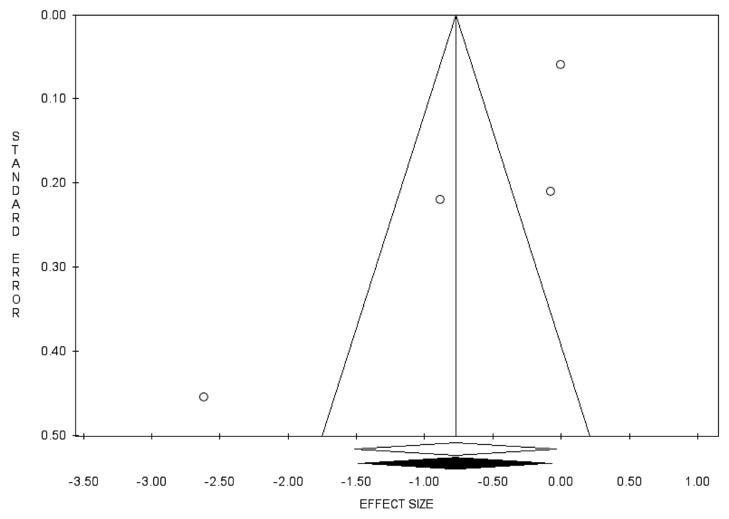

**Figure 8.** Funnel plots of the meta-analysis evaluating the association between use of 5-ARIs and the

RR of BCa recurrence. Egger’s linear regression (t = *−*2.39, *p* = 0.139) and Begg and Mazumdar rank

correlation test (z = *−*2.04, *p* = 0.042).

*Diagnostics* **2021**, *11*, 351

12 of 15

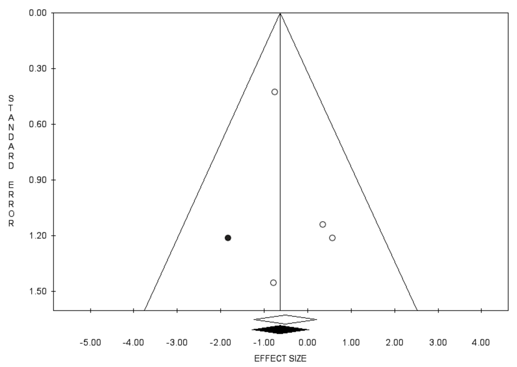

**Figure 9.** Funnel plots of the meta-analysis evaluating the association between use of 5-ARIS or

ADT and the RR of BCa progression. Egger’s linear regression (t = 1.46, *p* = 0.282) and Begg and

Mazumdar rank correlation test (z = 0.68, *p* = 0.497).

**4. Discussion**

The current evidence supports the hypothesis that BCa is a endocrine-related tumours

and that the modulation of androgen-dependent pathways can alter tumour behaviour [25].

Indeed3 androgen signalling can promote DNA breaks and chromosomal rearrangements,

leading to the formation of oncogenic fusion genes [3]. The modulation of androgen

signalling pathways as complementary strategy in BCa patients represents a promising ﬁeld

of investigation [25,26]. The results from the present systematic review demonstrate that

strategies aimed at suppressing androgen signalling can improve the outcomes of therapies

for BCa in both preclinical and clinical settings. The available preclinical evidence from both

in vitro and in vivo models demonstrate that the manipulation of androgen-dependent

pathways can interfere with the sensitivity of BCa to BCG, radiation, and chemotherapy.

In detail, the experimental negative modulation of the androgen-dependent pathway can

increase the amount of intracellular BCG, the rate of BCG positive cells, BCG efﬁcacy to

suppress BCa cell proliferation, BCG cytotoxic activity, and BCG-induced recruitment of

monocytes/macrophages. Moreover, the negative modulation of the androgen-dependent

pathway can enhance the sensitivity of the BCa cell lines to radiation and chemotherapy in

preclinical experimental settings. These ﬁndings are in line with immunohistochemical

ﬁndings showing that androgen receptor expression is associated with resistance to BCG

and to cisplatin [11,15].

Despite these ﬁndings, the differential impact of different subtypes of androgen

suppression modalities on BCa behaviour in preclinical models remains controversial.

Indeed, in their in vitro study, Nagata et al. demonstrated that, unlike androgen receptor

antagonists, 5-ARIs have no signiﬁcant impact on the development and progression of

urothelial cancer [27].

The clinical evidence synthesized in the present review demonstrates a statistically

signiﬁcantly lower risk of BCa recurrence in the overall population of patients undergoing

hormonal manipulation with ADT or 5-ARIs. One study included only patients undergoing

ADT and found it to be an independent prognosticator for BCa recurrence at multivariable

analysis (Hazard Ratio: 0.29; 95% CI: 0.17–0.49) [24]. The pooled analysis relative to

the subgroup of patients undergoing 5-ARIs therapy conﬁrmed a statistically signiﬁcant

reduction of BCa recurrence risk with respect to controls. Interestingly, we found, for

*Diagnostics* **2021**, *11*, 351

13 of 15

magnitude of the RR of BCa recurrence.

Despite the beneﬁcial effects in terms of BCa recurrence, the pooled data do not

support a protective role by ADT and/or therapy with 5-ARIs in terms of BCa progression

in the overall population of subjects evaluated. However, some subsets of patients may

beneﬁt from androgen suppression also in terms of progression. Wu et al. found that

therapy with ADT or 5-ARIs was potentially associated with lower progression rates in

patients with low/intermediate-risk BCa, but not in their high-risk counterparts. Indeed,

the 5-yr progression free survival with and without ADT or 5-ARIs was 49% versus 55%

(*p* = 0.76) in high-risk BCa and 100% versus 74% (*p* = 0.073) in low/intermediate-risk

BCa [20]. Studies evaluating the impact of therapy with 5-ARIs on BCa related mortality

provided conﬂicting results [18,19,23]. Taken together, these ﬁndings support a protective

role exerted by androgen suppression therapy mainly in the early phase of the natural

history of BCa. The beneﬁts provided by androgen suppression (obtained through 5-

available evidence, these advantages seem to be related to the aggressiveness of the disease.

These ﬁndings should be interpreted in light of previous evidence demonstrating that,

in BCa patients, androgen receptor expression inversely correlates with tumour grade

and stage [28]. Therefore, it can be hypothesized that the lower expression of androgen

receptors in patients with high-stage and high-grade tumours may represent the substrate

for the lower efﬁcacy of androgen suppression strategies in terms of both recurrence

and progression. Accordingly, Izumi et al. found that androgen receptor expression

in nonmuscle invasive BCa was a predictor of the preventive effect of ADT on tumour

recurrence [29]. The lower expression of androgen receptors in patients with high stage

and/or high grade BCa may also be responsible, in part, for the apparent discrepancy

between preclinical evidence obtained in cell lines in vitro demonstrating higher efﬁcacy

of BCG (a drug mainly prescribed to prevent BCa progression) following suppression

of androgen signalling and clinical evidence that do not conﬁrm the protective role of

androgen suppression in terms of BCa progression in the overall population. Unfortunately,

there are no clinical studies about the efﬁcacy of androgen suppression on the outcomes

of chemo/radiotherapy. The results from the present systematic review have relevant

clinical implications and pose the basis for further investigations ADT is widely adopted

in patients with metastatic disease and 5-ARIs have been evaluated extensively for the

primary prevention of prostate cancer [30]. The potential beneﬁt of 5-ARIs and ADT for

BCa patients is a recent ﬁnding. Based on this data, we can hypothesize a synergistic

effect by androgen suppression strategies and standard treatments in early stage BCa in

male patients. However, further studies are needed to conﬁrm these observations. Indeed,

given the concomitant bladder outﬂow beneﬁts and a favourable safety proﬁle, there is a

compelling rationale for the prospective evaluation of 5-ARIs as a secondary prevention

strategy for BCa recurrence in men [31–33]. Although androgen suppression has the

potential of being a means of radio- and chemiosensitization, further studies are needed to

conﬁrm this preclinical evidence.

The potential limits of the available literature must be acknowledged: the available

studies are few, often of low methodological quality, and with short follow-up. Moreover,

they enrol only male patients with heterogeneous BCa features and only a small percentage

of studies focused on patients undergoing RC or EBRT. Further studies are needed to

better investigate the role of androgen suppression in speciﬁc subgroups of BCa patients

(i.e., young versus older patients), to compare the effects of 5-ARIs to ADT, and to better

elucidate the impact of androgen manipulation strategies in patients with muscle invasive

disease undergoing RC or EBRT.

*Diagnostics* **2021**, *11*, 351

14 of 15

**5. Conclusions**

The suppression of androgen signalling improves BCa cell chemosensitivity and ra-

diosensitivity, as well as BCG efﬁcacy in the preclinical setting. The clinical evidence

demonstrates that the RR of BCa recurrence after TURBT is signiﬁcantly lower in patients

undergoing androgen suppression therapy with 5-ARIs/ADT compared to controls and

that the magnitude of this protective effect is inversely related to tumour stage. Despite the

existence of a trend toward the beneﬁts of androgen suppression in terms of BCa progres-

sion in patients with low-intermediate risk, these ﬁndings deserve further investigations.

**Author Contributions:** M.C. (Massimiliano Creta), V.M., C.I., G.C. (Giuseppe Celentano), L.N.

and N.L. conceived and designed the study; S.M., C.T., L.S. and R.L.R. collected the data; C.C.R.,

F.M., G.C. (Gianluigi Califano), F.F. and L.N. analysed the data; M.C. (Massimiliano Creta), M.C.

(Marco Capece), G.C. (Giuseppe Celentano) and N.L. wrote the paper. All authors have read and

agreed to the published version of the manuscript.

**Funding:** This research received no external funding.

**Institutional Review Board Statement:** Not applicable.

**Informed Consent Statement:** Not applicable.

**Data Availability Statement:** Not applicable.

**Acknowledgments:** None to declare.

**Conﬂicts of Interest:** The authors declare no conﬂict of interest.

**References**

1.

Cumberbatch, M.G.K.; Noon, A.P. Epidemiology, aetiology and screening of bladder cancer. *Transl. Androl. Urol.* **2019**, *8*, 5–11.

[CrossRef] [PubMed]

2.

Creta, M.; Mirone, V.; Di Meo, S.; Buonopane, R.; Fusco, F.; Imperatore, V. Endoscopic Spatulation of the Intramural Ureter: A

Technique to Prevent Stenosis of the Ureterovesical Junction in Patients Undergoing Resection of the Ureteral Oriﬁce. *J. Endourol.*

**2016**, *30*, 913–917. [CrossRef] [PubMed]

3.

Kim, A.; Kim, M.S.; Ahn, J.H.; Choi, W.S.; Park, H.K.; Kim, H.G.; Paick, S.H. Clinical signiﬁcance of 5-α reductase inhibitor and

andro-gen deprivation therapy in bladder cancer incidence, recurrence, and survival: A meta-analysis and systemic review. *Aging*

*Male* **2019**, *14*, 1–8. [CrossRef] [PubMed]

4.

Longo, N.; Imbimbo, C.; Fusco, F.; Ficarra, V.; Mangiapia, F.; Di Lorenzo, G.; Creta, M.; Imperatore, V.; Mirone, V. Complications

and quality of life in elderly patients with several comorbidities undergoing cutaneous ureterostomy with single stoma or ileal

conduit after radical cystectomy. *BJU Int.* **2016**, *118*, 521–526. [CrossRef] [PubMed]

5.

Venugopal, P.; Moorthy, H.K.; Prabhu, G.G.L. Clinical and therapeutic implications of sex steroid hormone receptor status in

urothelial bladder cancer. *Indian J. Urol.* **2020**, *36*, 171–178. [CrossRef]

6.

Boorjian, S.; Ugras, S.; Mongan, N.P.; Gudas, L.J.; You, X.; Tickoo, S.K.; Scherr, D.S. Androgen receptor expression is inversely

correlated with pathologic tumor stage in bladder cancer. *Urology* **2004**, *64*, 383–388. [CrossRef]

7.

Ide, H.; Miyamoto, H. Steroid Hormone Receptor Signals as Prognosticators for Urothelial Tumor. *Dis. Markers* **2015**, *2015*, 1–12.

[CrossRef]

8.

Antoni, S.; Ferlay, J.; Soerjomataram, I.; Znaor, A.; Jemal, A.; Bray, F. Bladder Cancer Incidence and Mortality: A Global Overview

and Recent Trends. *Eur. Urol.* **2017**, *71*, 96–108. [CrossRef] [PubMed]

9.

Liberati, A.; Altman, D.G.; Tetzlaff, J.; Mulrow, C.; Gøtzsche, P.C.; Ioannidis, J.P.; Clarke, M.; Devereaux, P.J.; Kleijnen, J.; Moher, D.

The PRISMA statement for reporting systematic reviews and meta-analyses of studies that evaluate health care interventions:

Explanation and elaboration. *PLoS Med.* **2009**, *6*, e1000100. [CrossRef]

10.

Sterne, J.A.; Hernán, M.A.; Reeves, B.C.; Savovi´c, J.; Berkman, N.D.; Viswanathan, M.; Henry, D.; Altman, D.G.; Ansari, M.T.;

Boutron, I.; et al. ROBINS-I: A tool for assessing risk of bias in non-randomised studies of interventions. *BMJ* **2016**, *12*, 355.

[CrossRef]

11.

Mizushima, T.; Jiang, G.; Kawahara, T.; Li, P.; Han, B.; Inoue, S.; Ide, H.; Kato, I.; Jalalizadeh, M.; Miyagi, E.; et al. Androgen

Receptor Signaling Reduces the Efﬁcacy of Bacillus Calmette-Guérin Therapy for Bladder Cancer via Modulating Rab27b-Induced

Exocytosis. *Mol. Cancer Ther.* **2020**, *19*, 1930–1942. [CrossRef]

12.

Ide, H.; Inoue, S.; Mizushima, T.; Jiang, G.; Chuang, K.H.; Oya, M.; Miyamoto, H. Androgen Receptor Signalling Reduces

Radiosensitivity in Bladder Cancer. *Mol. Cancer Ther.* **2018**, *17*, 1566–1574. [CrossRef]

13.

Shang, Z.; Li, Y.; Zhang, M.; Tian, J.; Han, R.; Shyr, C.R.; Messing, E.; Yeh, S.; Niu, Y.; Chang, C. Antiandrogen Therapy with

Hydroxyﬂutamide or Androgen Receptor Degradation Enhancer ASC-J9 Enhances BCG Efﬁcacy to Better Suppress Bladder

Cancer Progression. *Mol. Cancer Ther.* **2015**, *14*, 2586–2594. [CrossRef] [PubMed]

*Diagnostics* **2021**, *11*, 351

15 of 15

14.

Shiota, M.; Takeuchi, A.; Yokomizo, A.; Kashiwagi, E.; Tatsugami, K.; Kuroiwa, K.; Naito, S. Androgen Receptor Signaling

Regulates Cell Growth and Vulnerability to Doxorubicin in Bladder Cancer. *J. Urol.* **2012**, *188*, 276–286. [CrossRef]

15.

Kashiwagi, E.; Ide, H.; Inoue, S.; Kawahara, T.; Zheng, Y.; Reis, L.O.; Baras, A.S.; Miyamoto, H. Androgen receptor activity

modulates responses to cisplatin treatment in bladder cancer. *Oncotarget* **2016**, *7*, 49169–49179. [CrossRef] [PubMed]

16.

Kameyama, K.; Horie, K.; Mizutani, K.; Kato, T.; Fujita, Y.; Kawakami, K.; Kojima, T.; Miyazaki, T.; Deguchi, T.; Ito, M.

Enzalutamide inhibits proliferation of gemcitabine-resistant bladder cancer cells with increased androgen receptor expression.

*Int. J. Oncol.* **2017**, *50*, 75–84. [CrossRef]

17.

Al-Hogbani, M.; Gilbert, S.; Lodde, M.; Fradet, Y.; Toren, P. Does 5-alpha Reductase Inhibitor Use Improve The Efﬁcacy of

Intravesical Bacille Calmette-Guérin (BCG) for Non-muscle Invasive Bladder Cancer? *Bl. Cancer* **2020**, *6*, 63–69. [CrossRef]

18.

McMartin, C.; Lacombe, L.; Fradet, V.; Fradet, Y.; Lodde, M.; Toren, P. Receipt of 5-Alpha Reductase Inhibitors Before Radical

Cys-tectomy: Do They Render High-Grade Bladder Tumors Less Aggressive? *Clin. Genitourin. Cancer.* **2019**, *17*, e1122–e1128.

[CrossRef] [PubMed]

19.

Mäkelä, V.J.; Kotsar, A.; Tammela, T.L.; Murtola, T.J. Bladder Cancer Survival of Men Receiving 5α-Reductase Inhibitors. *J. Urol.*

**2018**, *200*, 743–748. [CrossRef]

20.

Wu, S.C.; Kwon, D.; Jue, J.S.; Chen, F.V.; Velasquez Escobar, M.C.; Punnen, S.; Parekh, D.J.; Ritch, C.R.; Gonzalgo, M.L. Androgen

Suppression Therapy Is Associated with Lower Recurrence of Non-muscle-invasive Bladder Cancer. *Eur. Urol. Focus* **2019**.

[CrossRef]

21.

Shiota, M.; Kiyoshima, K.; Yokomizo, A.; Takeuchi, A.; Kashiwagi, E.; Dejima, T.; Takahashi, R.; Inokuchi, J.; Tatsugami, K.; Eto,

M. Suppressed Recurrent Bladder Cancer after Androgen Suppression with Androgen Deprivation Therapy or 5α-Reductase

Inhibitor. *J. Urol.* **2017**, *197*, 308–313. [CrossRef]

22.

Pastore, A.L.; Fuschi, A.; De Nunzio, C.; Balzarro, M.; Al Salhi, Y.; Velotti, G.; Martoccia, A.; Capone, L.; Amigoni, N.; Falsaperla,

M.; et al. Possible role of 5-alpha reductase inhibitors in non-invasive bladder urothelial neoplasm: Multicentre study. *Minerva*

*Urol. Nefrol.* **2019**. [CrossRef]

23.

Wang, C.-S.; Li, C.-C.; Juan, Y.-S.; Wu, W.-J.; Lee, H.-Y. 5α-reductase inhibitors impact prognosis of urothelial carcinoma. *BMC*

*Cancer* **2020**, *20*, 1–7. [CrossRef]

24.

Izumi, K.; Taguri, M.; Miyamoto, H.; Hara, Y.; Kishida, T.; Chiba, K.; Murai, T.; Hirai, K.; Suzuki, K.; Fujinami, K.; et al. Androgen

deprivation therapy prevents bladder cancer recurrence. *Oncotarget* **2014**, *5*, 12665–12674. [CrossRef] [PubMed]

25.

Li, P.; Chen, J.; Miyamoto, H. Androgen Receptor Signaling in Bladder Cancer. *Cancers* **2017**, *9*, 20. [CrossRef]

26.

Morales, E.E.; Grill, S.; Svatek, R.S.; Kaushik, D.; Thompson, I.M., Jr.; Ankerst, D.P.; Liss, M.A. Finasteride Reduces Risk of Bladder

Cancer in a Large Prospective Screening Study. *Eur. Urol.* **2016**, *69*, 407–410. [CrossRef] [PubMed]

27.

Nagata, Y.; Goto, T.; Jiang, G.; Teramoto, Y.; Miyamoto, H. 5α-Reductase Inhibitors Do Not Prevent the Development and

Progression of Urothelial Cancer: In Vitro Evidence. *Bl. Cancer* **2020**, *6*, 1–8. [CrossRef]

28.

Chen, J.; Cui, Y.; Li, P.; Liu, L.; Li, C.; Zu, X. Expression and clinical signiﬁcance of androgen receptor in bladder cancer: A

meta-analysis. *Mol. Clin. Oncol.* **2017**, *7*, 919–927. [CrossRef]

29.

Izumi, K.; Ito, Y.; Miyamoto, H.; Miyoshi, Y.; Ota, J.; Moriyama, M.; Murai, T.; Hayashi, H.; Inayama, Y.; Ohashi, K.; et al.

Expression of androgen receptor in non-muscle-invasive bladder cancer predicts the preventive effect of androgen deprivation

therapy on tumor recurrence. *Oncotarget* **2016**, *7*, 14153–14160. [CrossRef] [PubMed]

30.

Buonerba, C.; Ferro, M.; Dolce, P.; Crocetto, F.; Verde, A.; Lucarelli, G.; Scafuri, L.; Facchini, S.; Vaia, A.; Marinelli, A.; et al.

Predictors of efﬁcacy of androgen-receptor-axis-targeted therapies in patients with metastatic castration-sensitive prostate cancer:

A systematic review and meta-analysis. *Crit. Rev. Oncol. Hematol.* **2020**, *151*, 102992. [CrossRef]

31.

Fusco, F.; Creta, M.; De Nunzio, C.; Gacci, M.; Li Marzi, V.; Finazzi Agrò, E. Alpha-1 adrenergic antagonists, 5-alpha reductase

inhibitors, phosphodiesterase type 5 inhibitors, and phytotherapic compounds in men with lower urinary tract symptoms

sug-gestive of benign prostatic obstruction: A systematic review and meta-analysis of urodynamic studies. *Neurourol. Urodyn.*

**2018**, *6*, 1865–1874.

32.

Fusco, F.; Arcaniolo, D.; Creta, M.; Piccinocchi, G.; Arpino, G.; Laringe, M.; Piccinocchi, R.; Longo, N.; Verze, P.; Mangiapia,

F.; et al. Demographic and comorbidity proﬁle of patients with lower urinary tract symptoms suggestive of benign prostatic

hyperplasia in a real-life clinical setting: Are 5-alpha-reductase inhibitor consumers different? *World J. Urol.* **2014**, *33*, 685–689.

[CrossRef] [PubMed]

33.

Kourbanhoussen, K.; McMartin, C.; Lodde, M.; Zlotta, A.; Bryan, R.T.; Toren, P. Switching Cancers: A Systematic Review

Assessing the Role of Androgen Suppressive Therapy in Bladder Cancer. *Eur. Urol. Focus* **2020**. [CrossRef] [PubMed]